# Tópico 2 - Movimento retilíneo

## Anderson M Amaral - amamaral.github.io/teaching

[figure not shown]

# Movimento retilíneo

### Fundamentos da Física, Capítulo 2

### Leituras complementares:

- Nussenzveig - Capítulo 2
- Feynman, Leighton, Sands - Capítulo 8

## Movimento de corpos

Ex.: como descrever o movimento de um trem ao longo de uma estrada de ferro?

[figure not shown]

### Aplicação do método científico

1. Observação: Iniciar pelos movimentos mais simples.

- Movimento em uma dimensão. Ex.: retas na vertical, diagonal, ou horizontal.

2. Abstração: Eliminar detalhes "irrelevantes".

- Movimento dado por um ponto de referência (ex.: extremidade).

3. Formulação de conceitos para descrever o movimento.
4. Domínio de validade: quando os detalhes se tornam relevantes.

## Conceitos básicos: localização

1. Região onde o movimento ocorre. Ex.: Reta vertical
2. Referência para posicionamento. Origem.
3. Orientação. Positivo e negativo.
4. Unidades. (m)
5. Posição. (x=-0,7 m)

[figure not shown]

## Conceitos básicos: deslocamento

Deslocamento $\Delta x$: $$ \Delta x = x_2 - x_1 = x_f-x_i $$

1. Sinal (positivo ou negativo) indica orientação.

- Grandeza de natureza vetorial.

2. Ex.: Seja $x_i = 3,2\text{ m}$, e $x_f = 2,0\text{ m}$

[figure not shown]

## Conceitos básicos: deslocamento

Deslocamento $\Delta x$: $$ \Delta x = x_2 - x_1 = x_f-x_i $$

1. Sinal (positivo ou negativo) indica orientação.

- Grandeza de natureza vetorial.

2. Ex.: Seja $x_i = 3,2\text{ m}$, e $x_f = 2,0\text{ m}$ : $\Delta x = -1,2\text{ m}$

[figure not shown]

## Atenção

- O deslocamento tem natureza vetorial e $\Delta x$ pode ser negativo.
- Seu módulo, $|\Delta x|$ é sempre positivo, mas
- Não confundir $|\Delta x|$ com a distância percorrida!

### Exemplo:

Uma partícula sofre um deslocamento $3,4\text{ m}$ e depois recua os mesmos $3,4\text{ m}$.

(a) Qual a distância percorrida? $3,4 + 3,4 = 6,8\text{ m}$.

(b) Qual o módulo do deslocamento? $|3,4 - 3,4| = 0\text{ m}$.

## Movimento e o tempo

- Podemos representar o movimento como uma posição, $x$, que varia com o tempo $t$.
- Posição: $x(t)$ (função do tempo).
- $x(t)$ pode ser representada graficamente.

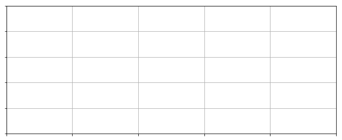

```python
# A blank grid for manual data representation on blackboard

xticks(arange(0,11,2),[])
yticks(arange(0,11,2),[])
grid()
```

## Exemplo

- Representar $x(t) = x_0 = $ constante.

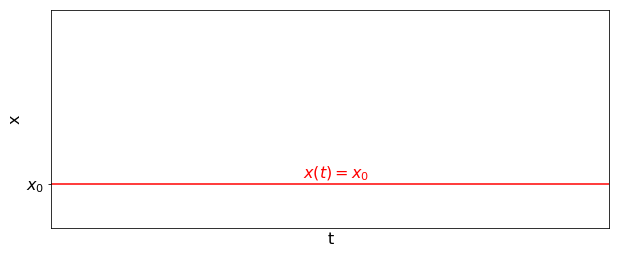

```python
h = 2 #Altura "visual" da constante

hlines(h, 0, 11, color='red')
text(4.5, h+.3, '$x(t)=x_0$', color='red')

xticks([])
yticks([h],['$x_0$'])
xlim(0,10)
ylim(0,10)

xlabel('t')
ylabel('x')
```

## Exemplo

- Considere um esquilo parado ao junto a uma árvore. Após 5 s, o esquilo percebe um lobo se aproximando, e começa a subir na árvore, só sossegando após chegar à um galho a 4 m de altura do solo. O trajeto entre o chão e o galho leva cerca de 10 s.
- Supondo que o eixo $x$ esteja ao longo da árvore, com origem $x$ = 0 m no solo, esboce o gráfico de $x(t)$ da posição do esquilo

### Etapas do movimento do esquilo

- 'I': Esquilo ao pé da árvore
- 'II': Esquilo subindo a árvore
- 'III': Esquilo parado no galho

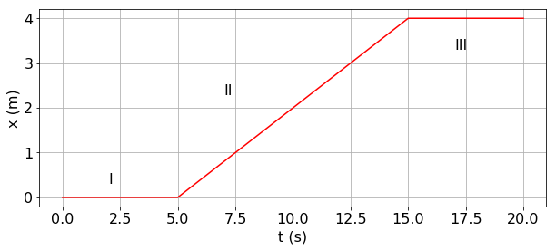

```python
# Coordenadas x e y dos pontos como "arrays"

x = array([0.0, 5.0, 15.0, 20.0])
y = array([0.0, 0.0, 4.0, 4.0])

# Representação gráfica dos pontos (x,y) acima
plot(x,y,'r-')

text(2, 0.3, "I")
text(7, 2.3, "II")
text(17, 3.3, "III")

xlabel("t (s)")
ylabel("x (m)")
grid()
```

## Velocidade média $(\bar{v})$

- Quão rápido uma partícula se move?
- Vel. média num intervalo $[t_1, t_2]$:

  $$ \bar{v} = \frac{x(t_2) - x(t_1)}{t_2 - t_1} = \frac{x_2 - x_1}{t_2 - t_1}$$

  No SI, $\bar{v}$ tem unidades m/s.
- Importante: independe dos detalhes do movimento.

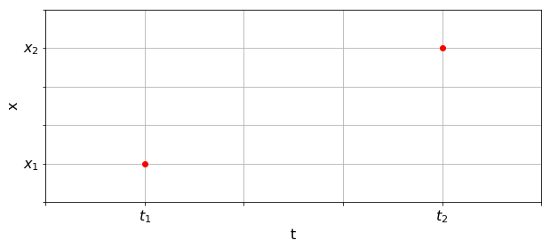

```python
# Coordenadas x e y dos pontos como "arrays"

x = array([2, 8])
y = array([2, 8])

# Representação gráfica dos pontos (x,y) acima
plot(x,y,'ro')

xlabel("t")
ylabel("x")
xticks(arange(0,11,2),['','$t_1$','','','$t_2$'])
yticks(arange(0,11,2),['','$x_1$','','','$x_2$'])
grid()
```

## Exemplo

Calcule $\bar{v}$ no intervalo $[1\text{ s},4\text{ s}]$, quando $x(t)=5t^2-t^3$.

$x(1\text{ s}) = 4$ m, e $x(4\text{ s}) = 16$ m.

$\bar{v} =$ $\frac{\Delta x}{\Delta t} = $ $ \frac{x(4)-x(1)}{4-1} = $ $ \frac{12}{3} = 4$

$\bar{v}$ é associado com a inclinação da secante. ver WolframAlpha.com.

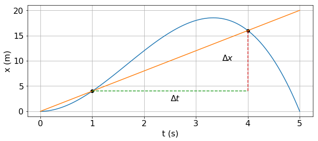

```python
# Coordenadas x e y dos pontos como "arrays"

t = linspace(0,5,100)

x = 5*t**2 - t**3

# Representação da função
plot(t,x)

plot([1,4], [4, 16], 'ko') # Pontos em t=1s e 4s
plot([0,5], [0, 20])       # Secante
plot([1,4], [4, 4],  '--') # Delta t
plot([4,4], [4, 16], '--') # Delta x

text(3.5, 10, '$\Delta x$')
text(2.5, 2,  '$\Delta t$')

xlabel("t (s)")
ylabel("x (m)")
grid()
```

## Velocidade instantânea $v$

- Velocidade relevante p. ex. em acidentes!
- Como obter $v$?
- R.: Usando intervalos de tempo $(\Delta t)$ cada vez menores.

#### Exemplo

Considere uma bola em queda livre, tal que $x(t)=\frac{gt^2}{2}\approx5t^2$, e que $t_2 = t_1 + \Delta t$, onde $t_1 = 1 $ s.

```
<ipywidgets.widgets.interaction._InteractFactory at 0x1d0e2b65048>
```

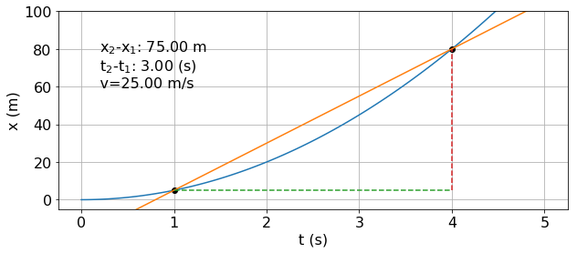

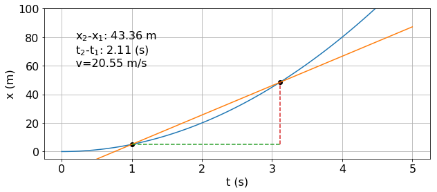

```python
from __future__ import print_function
from ipywidgets import interact, interactive, fixed, interact_manual
import ipywidgets as widgets
from ipykernel.pylab.backend_inline import flush_figures

def plot_secant(x):
    flush_figures()
    dt = x
    # Coordenadas x e y dos pontos como "arrays"

    t = linspace(0,5,100)

    x = 5*t**2

    # Representação da função
    plot(t,x)

    # Representação da secante
    t1 = 1
    t2 = t1 + dt
    x1 = 5
    x2 = 5*t2**2

    dx = x2-x1

    a = dx/dt
    b = 5 - a

    plot([t1,t2], [x1, x2], 'ko')  # Pontos em t=1s e 4s
    plot([0,5], [b, a*5+b])        # Secante
    plot([t1,t2], [x1, x1], '--')  # Delta t
    plot([t2,t2], [x1, x2], '--')  # Delta x

    text(0.0, 60, """    x$_2$-x$_1$: %.2f m
    t$_2$-t$_1$: %.2f (s)
    v=%.2f m/s""" % (dx, dt, dx/dt))

    xlabel("t (s)")
    ylabel("x (m)")
    ylim(-5,100)
    grid()

interact(plot_secant, x=widgets.FloatSlider(min=0.01,max=4.0,step=0.01,value=3, description=r'$\Delta t$'));
interact()
```

## Velocidade instantânea $v$ (definição)

$$v = \lim_{\Delta t \rightarrow 0}\frac{x(t+\Delta t)-x(t)}{\Delta t} = \frac{dx}{dt}$$

- $v=\frac{dx}{dt}$ é a "derivada de $x$ em relação a $t$".
- Mas, $x$ é função de $t$: derivada é a taxa de variação da posição.
- Unidade: $v=\frac{dx}{dt} \rightarrow \frac{\text{m}}{\text{s}}$ (no SI).

## Intuição geométrica para $v$

Represente a velocidade de um certo elevador que realiza o seguinte movimento. Inicialmente ele está parado no intervalo [0 s, 1 s], e que acelera uniformemente entre 1 s e 3 s. Sabe-se que $x(3) = 4$ m. Entre 3 s e 8 s, o elevador se move a uma velocidade uniforme, atingindo $x(8) = 24$ m, e desacelerando até o repouso total em $t=9$ s.

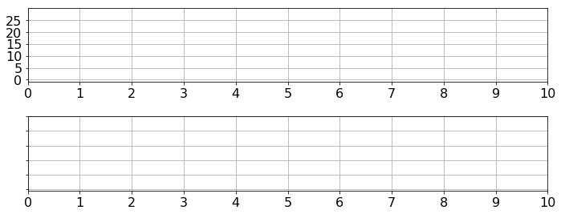

```python
subplot(211)
grid()
ylim(-1, 30)
yticks(arange(6)*5)
xticks(arange(11))

subplot(212)
grid()
ylim(-0.1,5)
yticks(arange(6), [])
xticks(arange(11))

tight_layout()
```

## Intuição geométrica para $v$

Represente a velocidade de um certo elevador que realiza o seguinte movimento. Inicialmente ele está parado no intervalo [0 s, 1 s], e que acelera uniformemente entre 1 s e 3 s. Sabe-se que $x(3) = 4$ m. Entre 3 s e 8 s, o elevador se move a uma velocidade uniforme, atingindo $x(8) = 24$ m, e desacelerando até o repouso total em $t=9$ s.

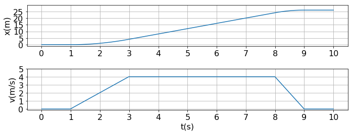

```python
t = linspace(0, 10, 500)
dt = t[1]-t[0]

a = 2*(greater_equal(t,1)*less_equal(t, 3))-4*(greater_equal(t,8)*less_equal(t, 9))

vi = 0
v = vi + a.cumsum()*dt # The last term is equivalent to the time integral of a

xi = 0
x = xi + v.cumsum()*dt # The last term is equivalent to the time integral of v

subplot(211)
plot(t, x)
grid()
ylim(-1, 30)
yticks(arange(6)*5)
xticks(arange(11))
ylabel('x(m)')

subplot(212)
plot(t, v)
grid()
ylim(-0.1,5)
yticks(arange(6))
xticks(arange(11))
ylabel('v(m/s)')
xlabel('t(s)')

tight_layout()
```

### Pergunta:

Se sabemos $x(t)$, vimos que é possível obter $v(t)$. **Conhecendo $v(t)$, é possível obter $x(t)$?**

- Problema inverso!

R.: A **área sob o gráfico** de $v(t)$ representa o deslocamento da partícula.

### Retornando ao exemplo do elevador...

Áreas nos respectivos intervalos:

- I [1s, 3s]: $\frac{2\cdot4}{2}=4$ m
- II [3s, 8s]: $5\cdot4=20$ m
- III[8s, 9s]: $\frac{1\cdot4}{2}=2$ m

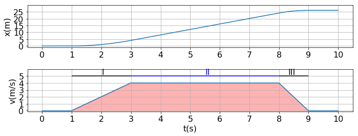

```python
subplot(211)
plot(t, x)
grid()
ylim(-1, 30)
yticks(arange(6)*5)
xticks(arange(11))
ylabel('x(m)')

subplot(212)
plot(t, v)
fill_between(t, v, 0, alpha=0.3, color='red')
grid()
ylim(-0.1,6)
yticks(arange(6))
xticks(arange(11))
ylabel('v(m/s)')
xlabel('t(s)')

h = 5
text(2, h+0.2, "I")
hlines(h, 1,3)
text(5.5, h+0.2, "II", color='b')
hlines(h, 3, 8, colors='b')
text(8.3, h+0.2, "III")
hlines(h, 8,9)

tight_layout()
```

## Cálculo analítico de $v$

- Retornemos ao exemplo da bola em queda livre. $x(t)=5t^2$. Calcular $v$ em $t=1$ s.

$v = \lim_{\Delta t \rightarrow 0}\frac{x(t+\Delta t)-x(t)}{\Delta t} =$ $\lim_{\Delta t \rightarrow 0}\frac{5(1+\Delta t)^2-5(1)}{\Delta t}=$ $\lim_{\Delta t \rightarrow 0}\frac{5(1+2\Delta t+\Delta t^2)-5}{\Delta t}=$ $\lim_{\Delta t \rightarrow 0}(10+5\Delta t)=10\frac{m}{s}$

```python
from __future__ import print_function
from ipywidgets import interact, interactive, fixed, interact_manual
from ipykernel.pylab.backend_inline import flush_figures
import ipywidgets as widgets

def plot_secant(x):
    dt = x
    # Coordenadas x e y dos pontos como "arrays"

    t = linspace(0,5,100)

    x = 5*t**2

    # Representação da função
    plot(t,x)

    # Representação da secante
    t1 = 1
    t2 = t1 + dt
    x1 = 5
    x2 = 5*t2**2

    dx = x2-x1

    a = dx/dt
    b = 5 - a

    plot([t1,t2], [x1, x2], 'ko')  # Pontos em t=1s e 4s
    plot([0,5], [b, a*5+b])        # Secante
    plot([t1,t2], [x1, x1], '--')  # Delta t
    plot([t2,t2], [x1, x2], '--') # Delta x

    text(0.0, 60, r"""    $\Delta x$: %.2f m
    $\Delta t$: %.2f (s)
    $\bar{v}$=%.2f m/s""" % (dx, dt, dx/dt))

    xlabel("t (s)")
    ylabel("x (m)")
    ylim(-5,100)
    grid()

    flush_figures()

interact(plot_secant, x=widgets.FloatSlider(min=0.01,max=4.0,step=0.01,value=3, description=r'$\Delta t$'));
```

#### Exemplo:

Calcular derivada de $x(t)=ct^3$, onde $c=$cte.

$\frac{dx}{dt} = \lim_{\Delta t \rightarrow 0}\frac{x(t+\Delta t)-x(t)}{\Delta t}=$ $\lim_{\Delta t \rightarrow 0}\frac{c(t+\Delta t)^3-ct^3}{\Delta t}=$ $c \lim_{\Delta t \rightarrow 0}\frac{(t^3+3t^2\Delta t+3t\Delta t^2 + \Delta t^3)-t^3}{\Delta t}=$ $c \lim_{\Delta t \rightarrow 0}(3t^2+3t\Delta t + \Delta t)=3ct^2$

(Supondo $c>0$ abaixo)

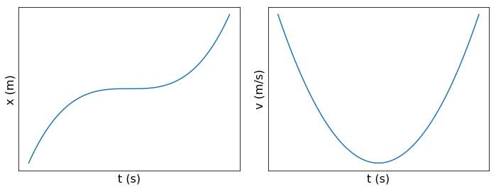

```python
t = linspace(-3,3,100)
c = 1
x = c*t**3
v = 3*c*t**2

subplot(121)
plot(t, x)
xlabel('t (s)')
ylabel('x (m)')
xticks([])
yticks([])

subplot(122)
plot(t, v)
xlabel('t (s)')
ylabel('v (m/s)')
xticks([])
yticks([])

tight_layout()
```

## Algumas regras de derivação

(ver apêndice no livro-texto)

Sejam $f(t)$ e $g(t)$ duas funções quaisquer* e $c=cte$,

- $\frac{d(c)}{dt} = 0$
- $\frac{d(cf)}{dt} = c\frac{df}{dt}$
- $\frac{d(f+g)}{dt} = \frac{df}{dt}+\frac{dg}{dt}$
- $\frac{d(f\cdot g)}{dt} = \frac{df}{dt}g(t)+f(t)\frac{dg}{dt}$
- $\frac{d(t^n)}{dt} = nt^{n-1}$
- $\frac{df[g(t)]}{dt} = \frac{df}{dg}\frac{dg}{dt}$

(*) Detalhes apresentados no curso de cálculo!

#### Exemplos

(a) $x(t)=x_0=$ cte. $v=\frac{dx}{dt}=?$

$v=\frac{dx}{dt}=0$

(Taxa de var. de uma constante = 0)

Gráfico?

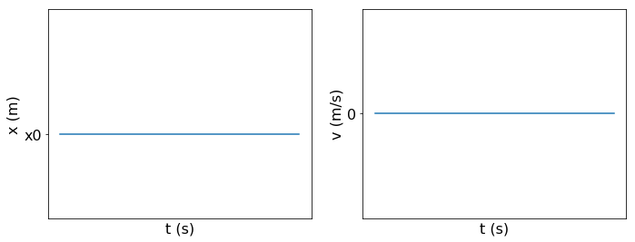

```python
t = linspace(0,1,2)
x = ones(t.shape) * 2
v = zeros(t.shape)

subplot(121)
plot(t, x)
xlabel('t (s)')
ylabel('x (m)')
xticks([])
ylim(0,5)
yticks([2],['x0'])

subplot(122)
plot(t, v)
xlabel('t (s)')
ylabel('v (m/s)')
xticks([])
yticks([0])

tight_layout()
```

#### Exemplos

(b) $x(t)=x_0+v_0t$. $v=\frac{dx}{dt}=?$

$v=\frac{d(x_0+v_0t)}{dt}=$ $0 + v_0\frac{dt}{dt}=$ $v_0$

Gráfico? (Assumindo $x_0=0, v_0>0$)

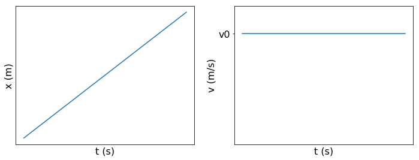

```python
t = linspace(0,1,2)
v0=2
x = v0*t
v = v0*ones(t.shape)

subplot(121)
plot(t, x)
xlabel('t (s)')
ylabel('x (m)')
xticks([])
yticks([])

subplot(122)
plot(t, v)
xlabel('t (s)')
ylabel('v (m/s)')
xticks([])
ylim(0,2.5)
yticks([2],['v0'])

tight_layout()
```

#### Exemplos

(b) $x(t)=x_0+v_0t+a\frac{t^2}{2}$. $v=\frac{dx}{dt}=?$

$v=\frac{d(x_0+v_0t+a\frac{t^2}{2})}{dt}=$ $v_0+\frac{a}{2}\frac{d(t^2)}{dt}=$ $v_0+a t$

Gráfico? (Assumindo $x_0=0, v_0>0, a<0$)

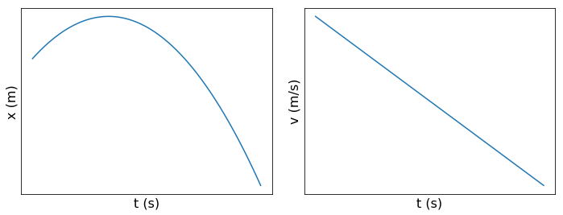

```python
t = linspace(0,6,100)
v0=2
a=-1
x = v0*t+a*t**2/2
v = v0+a*t

subplot(121)
plot(t, x)
xlabel('t (s)')
ylabel('x (m)')
xticks([])
yticks([])

subplot(122)
plot(t, v)
xlabel('t (s)')
ylabel('v (m/s)')
xticks([])
yticks([])

tight_layout()
```

## Aceleração

- $a$ indica a variação da velocidade
- Acel. média no intervalo $[t_1, t_2]$: $\bar{a} = $$\frac{v(t_2)-v(t_1)}{t_2-t_1}=\frac{\Delta v}{\Delta t}$
- Acel. instantânea: $a(t) = $$\lim_{\Delta t \rightarrow 0}\frac{v(t+\Delta t)-v(t)}{\Delta t} = \frac{dv}{dt}$
- Unidade de $a$ (no SI): $\rightarrow$$\frac{\Delta v}{\Delta t}=\frac{m/s}{s}=\frac{m}{s^2}$

Em termos de $x(t)$, $a(t) = \frac{dv}{dt} = \frac{d}{dt}\left(\frac{dx}{dt}\right) $$ = \frac{d^2x}{dt^2} $(segunda derivada da posição)

## O elevador mais uma vez...

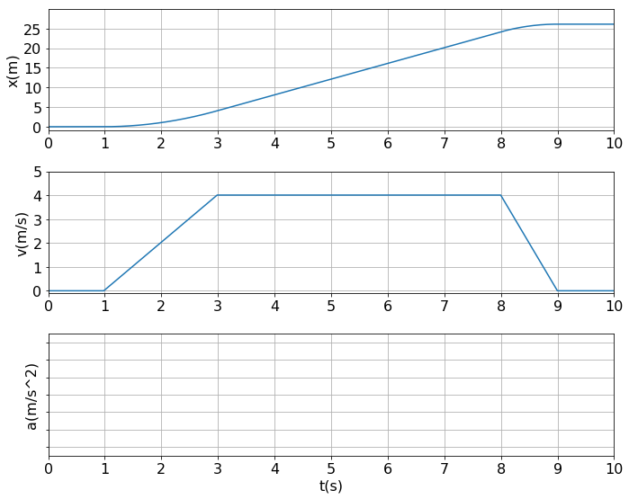

```python
figsize(10,8)
t = linspace(0, 10, 500)
dt = t[1]-t[0]

a = 2*(greater_equal(t,1)*less_equal(t, 3))-4*(greater_equal(t,8)*less_equal(t, 9))

vi = 0
v = vi + a.cumsum()*dt # The last term is equivalent to the time integral of a

xi = 0
x = xi + v.cumsum()*dt # The last term is equivalent to the time integral of v

subplot(311)
plot(t, x)
grid()
xlim(0,10)
ylim(-1, 30)
yticks(arange(6)*5)
xticks(arange(11))
ylabel('x(m)')

subplot(312)
plot(t, v)
grid()
xlim(0,10)
ylim(-0.1,5)
yticks(arange(6))
xticks(arange(11))
ylabel('v(m/s)')

subplot(313)
grid()
xlim(0,10)
ylim(-4.5,2.5)
yticks(arange(7)-4,[])
xticks(arange(11))
ylabel('a(m/s^2)')
xlabel('t(s)')

tight_layout()

figsize(*default_figsize)
```

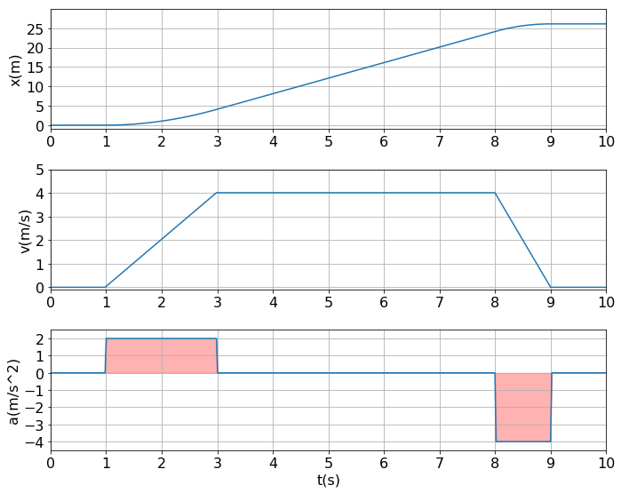

```python
figsize(10,8)
t = linspace(0, 10, 500)
dt = t[1]-t[0]

a = 2*(greater_equal(t,1)*less_equal(t, 3))-4*(greater_equal(t,8)*less_equal(t, 9))

vi = 0
v = vi + a.cumsum()*dt # The last term is equivalent to the time integral of a

xi = 0
x = xi + v.cumsum()*dt # The last term is equivalent to the time integral of v

subplot(311)
plot(t, x)
grid()
xlim(0,10)
ylim(-1, 30)
yticks(arange(6)*5)
xticks(arange(11))
ylabel('x(m)')

subplot(312)
plot(t, v)
grid()
xlim(0,10)
ylim(-0.1,5)
yticks(arange(6))
xticks(arange(11))
ylabel('v(m/s)')

subplot(313)
plot(t, a)
fill_between(t, a, 0, color='r', alpha=0.3)
grid()
xlim(0,10)
ylim(-4.5,2.5)
yticks(arange(7)-4)
xticks(arange(11))
ylabel('a(m/s^2)')
xlabel('t(s)')

tight_layout()

figsize(*default_figsize)
```

### Caso particular: $a=a_0=$ cte

-Importante em casos como queda livre próximo a superfície terrestre, onde $g\approx 9,8\text{ m/s}^2$.

- Como obter $v$ partindo de $a$? E $x$ partindo do $v$ obtido?

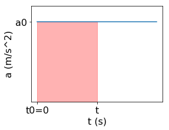

```python
figsize(4,3)
t = linspace(0,2,3)
a = ones(t.shape) * 1

plot(t, a)
fill_between(t[0:2],a[0:2],0,color='r',alpha=0.3)
xlabel('t (s)')
ylabel('a (m/s^2)')
xticks([])
ylim(0,1.2)
yticks([1],['a0'])
xticks([0,1], ['t0=0', 't'])
figsize(*default_figsize)
```

- Área sombreada: $a t = \Delta v$, ou $v=v_0+a t$.

#### E $x(t)$?

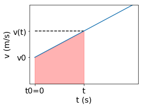

```python
figsize(4,3)
t = linspace(0,2,3)
v = 1 + t

plot(t, v)
fill_between(t[0:2],v[0:2],0,color='r',alpha=0.3)
xlabel('t (s)')
ylabel('v (m/s)')
xticks([])
ylim(0,3)
yticks([1, 2],['v0', 'v(t)'])
xticks([0,1], ['t0=0', 't'])
hlines(2, 0, 1, linestyles='dashed')

figsize(*default_figsize)
```

- Área sombreada: $\Delta x = \frac{[v_0 + v(t)]t}{2}$ = $\frac{[v_0 + v_0+at]t}{2} =$ $v_0 t + a \frac{t^2}{2}$

  $x = x_0 + v_0 t + a \frac{t^2}{2}$
- Obtivemos a equação da posição partindo diretamente da curva de aceleração!
- Podemos eliminar o tempo das equações: $ v = v_0 + a t $ $\rightarrow t = \frac{v-v_0}{a}$
- Substituindo na equação da posição,
- $x = x_0 + v_0 t + a\frac{t^2}{2}$ $\rightarrow x = x_0 + v_0 \frac{v-v_0}{a} + a\frac{(v-v_0)^2}{2a^2}$
- $ x - x_0 = \frac{v_0 v}{a} - \frac{v_0^2}{a} + \frac{(v^2-2v v_0 +v_0^2)}{2a}$
- $ x - x_0 = \frac{(v^2 -v_0^2)}{2a}$
- $ v^2 = v_0^2 + 2 a (x - x_0) \rightarrow$ Eq. de Torricelli
- Importante! A eq. de Torricelli só vale para $a=cte$!

# Exemplo: queda livre

- Supor um objeto arremessado para cima
- Consideremos que o movimento ocorre no eixo vertical apenas ($x\rightarrow y$).
- $a=-9,8\text{ m/s}^2\rightarrow$ y cresce "para cima".

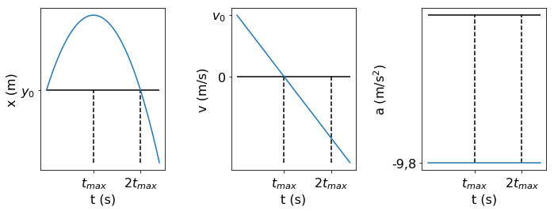

```python
t = linspace(0,6,100)
v0=25
a=-10
x = v0*t+a*t**2/2
v = v0+a*t

tmax = -v0/a

subplot(131)
plot(t, x)
xlabel('t (s)')
ylabel('x (m)')
hlines(0, t.min(), t.max())
vlines(tmax, x.min(), 0, linestyles='dashed')
vlines(2*tmax, x.min(), 0, linestyles='dashed')
xticks([tmax, 2*tmax], ['$t_{max}$', '$2t_{max}$'])
yticks([0], ['$y_0$'])

subplot(132)
plot(t, v)
xlabel('t (s)')
ylabel('v (m/s)')
hlines(0, t.min(), t.max())
vlines(tmax, v.min(), 0, linestyles='dashed')
vlines(2*tmax, v.min(), 0, linestyles='dashed')
xticks([tmax, 2*tmax], ['$t_{max}$', '$2t_{max}$'])
yticks([v0, 0], ['$v_0$', 0])

subplot(133)
plot(t, a*ones(t.shape))
xlabel('t (s)')
ylabel('a (m/s$^2$)')
hlines(0, t.min(), t.max())
vlines(tmax, -10, 0, linestyles='dashed')
vlines(2*tmax, -10, 0, linestyles='dashed')
xticks([tmax, 2*tmax], ['$t_{max}$', '$2t_{max}$'])
yticks([-10], ['-9,8'])

tight_layout()
```